# PM2.5 US 1999 - 2008

Linda Angulo Lopez

30/09/2020

## [Assignment](https://www.coursera.org/learn/exploratory-data-analysis/peer/b5Ecl/course-project-2)

The overall goal of this assignment is to explore the National Emissions Inventory database and see what it say about fine particulate matter pollution in the United states over the 10-year period 1999 to 2008.

- set up environment

```r
setwd("C:/Users/angul/OneDrive/R/ExploreData/Data")

library(ggplot2)
library(dplyr)
library(RColorBrewer)

NEI <- readRDS("summarySCC_PM25.rds")
SCC <- readRDS("Source_Classification_Code.rds")
```

### Q1. Have total emissions from PM2.5 decreased in the United States from 1999 to 2008? Using the base plotting system, make a plot showing the total PM2.5 emission from all sources for each of the years 1999, 2002, 2005, and 2008. Upload a PNG file containing your plot addressing this question.

```r
# emissions by year
total_emmissions <- aggregate(Emissions ~ year, NEI, sum)

png("Q1_53pcdropspike.png", width=480, height=480)
barplot(
  (total_emmissions$Emissions)/10^6,
  names.arg=total_emmissions$year,
  xlab="Year",
  ylab="PM2.5 Emissions (10^6 Tons)",
  ylim = c(0, 7.5),
  col="black",
  border="red",
  main="53% PM2.5 emission drop from 1999 to 2008, over the USA")
dev.off()
```

```r
print("Percent Total emissions change: ")
```

```
## [1] "Percent Total emissions change: "
```

```r
pcdiff <- ((total_emmissions[4,2] - total_emmissions[1,2])/total_emmissions[1,2])*100
print(pcdiff)
```

```
## [1] -52.75847
```

`scratch space`

```r
NEI <- readRDS("summarySCC_PM25.rds")
SCC <- readRDS("Source_Classification_Code.rds")

head(total_emmissions)
```

```
##   year Emissions
## 1 1999   7332967
## 2 2002   5635780
## 3 2005   5454703
## 4 2008   3464206
```

```r
totUS1999 <- total_emmissions[1,2]
print("The total US PM2.5 emmissions in 1999 were:")
```

```
## [1] "The total US PM2.5 emmissions in 1999 were:"
```

```r
print(totUS1999, useSource=TRUE)
```

```
## [1] 7332967
```

```r
totUS2008 <- total_emmissions[4,2]
print("while that of 2008 sttod at:")
```

```
## [1] "while that of 2008 sttod at:"
```

```r
print(totUS2008, useSource=TRUE)
```

```
## [1] 3464206
```

```r
difftotUS <- total_emmissions[1,2] - total_emmissions[4,2]
pcdiff <- (total_emmissions[1,2] - total_emmissions[4,2])/total_emmissions[1,2]
```

### Q2. Have total emissions from PM2.5 decreased in the Baltimore City, Maryland ( fips == 24510) from 1999 to 2008? Use the base plotting system to make a plot answering this question.

```r
setwd("C:/Users/angul/OneDrive/R/ExploreData/Data")

library(ggplot2)
library(dplyr)
library(RColorBrewer)

NEI <- readRDS("summarySCC_PM25.rds")
SCC <- readRDS("Source_Classification_Code.rds")

baltimore <- subset(NEI, fips=="24510")
totPM25_Baltimore <- aggregate(Emissions ~ year, baltimore, sum)

png("Q2_43dropBalt2015spike.png", width=480, height=480)
barplot(
  totPM25_Baltimore$Emissions,
  names.arg=totPM25_Baltimore$year,
  xlab="Year",
  ylab="PM2.5 Emissions, in Tons",
  ylim=c(0,3500),
  col="black",
  border="red",
  main="43% drop: despite 2005 spike in Baltimore City" )
dev.off()
```

```r
pcdiffBalt <- (totPM25_Baltimore[1,2] - totPM25_Baltimore[4,2])/totPM25_Baltimore[1,2]
print("Percent Total emissions change: ")
```

```
## [1] "Percent Total emissions change: "
```

```r
print(pcdiffBalt)
```

```
## [1] 0.431222
```

`scratch space`

```r
head(totPM25_Baltimore)
```

```
##   year Emissions
## 1 1999  3274.180
## 2 2002  2453.916
## 3 2005  3091.354
## 4 2008  1862.282
```

```r
totBalt1999 <- totPM25_Baltimore[1,2]
print("The total Baltimore PM2.5 emmissions in 1999 were:")
```

```
## [1] "The total Baltimore PM2.5 emmissions in 1999 were:"
```

```r
print(totBalt1999, useSource=TRUE)
```

```
## [1] 3274.18
```

```r
totBalt2008 <- totPM25_Baltimore[1,2]
print("while that of 2008 stood at:")
```

```
## [1] "while that of 2008 stood at:"
```

```r
print(totBalt2008, useSource=TRUE)
```

[output not shown]

```r
difftotBalt <- totPM25_Baltimore[1,2] - totPM25_Baltimore[4,2]
pcdiffBalt <- (totPM25_Baltimore[1,2] - totPM25_Baltimore[4,2])/totPM25_Baltimore[1,2]
print("Percent Total emissions change: ")
```

```
## [1] "Percent Total emissions change: "
```

```r
print(pcdiffBalt)
```

```
## [1] 0.431222
```

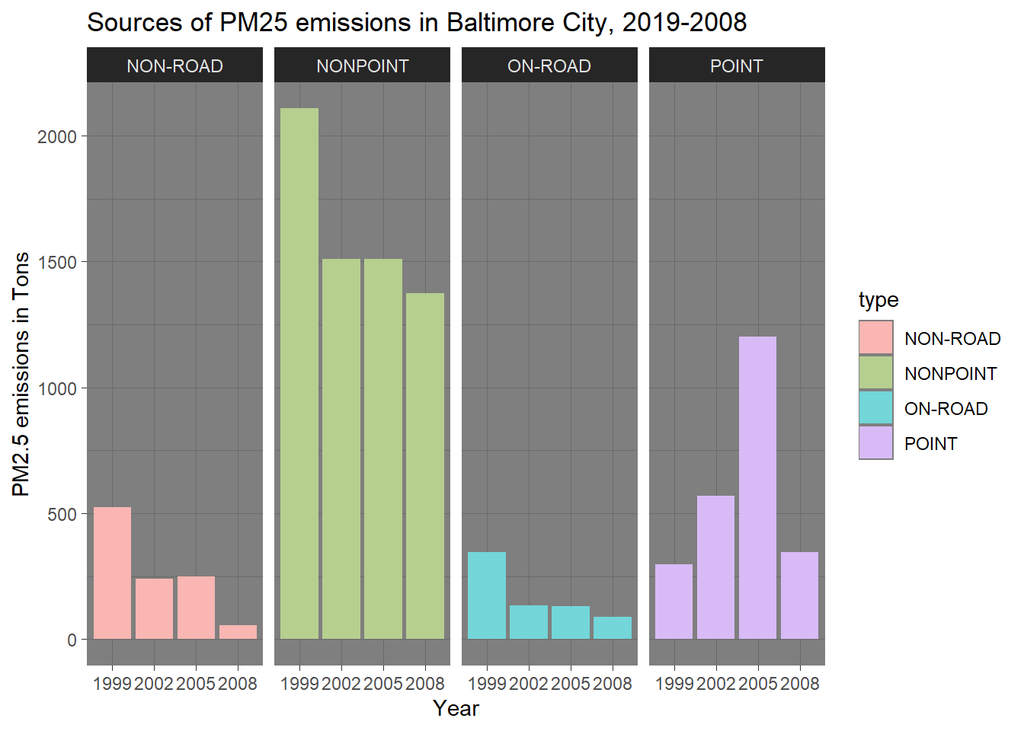

```r
setwd("C:/Users/angul/OneDrive/R/ExploreData/Data")

library(ggplot2)
library(dplyr)
library(RColorBrewer)

NEI <- readRDS("summarySCC_PM25.rds")
SCC <- readRDS("Source_Classification_Code.rds")

tot_emi_24510_by_type <- NEI %>%
        filter(fips == 24510) %>%
        select(fips, type, Emissions, year) %>%
        group_by(year, type) %>%
        summarise(Total_Emissions = sum(Emissions, na.rm = TRUE))
SourcePM25Baltimore <- ggplot(tot_emi_24510_by_type, aes(x = factor(year), y = Total_Emissions, fill = type)) +
        geom_bar(stat = "identity") +
        facet_grid(.~type) +
        labs(x = "Year", y = "PM2.5 emissions in Tons", title = "Sources of PM25 emissions in Baltimore City, 2019-2008")+
        theme(plot.title = element_text(size = 14),
              axis.title.x = element_text(size = 12),
              axis.title.y = element_text(size = 12)) +
        scale_fill_hue(c=45, l=80) +
        theme_dark() +
        ggsave("Q3_SourcePM25Baltimore.png", width = 25, height = 20, units = "cm")

print(SourcePM25Baltimore)
```

`scratch space`

```r
head(tot_emi_24510_by_type)
```

```
## # A tibble: 6 x 3
## # Groups:   year [2]
##    year type     Total_Emissions
##   <int> <chr>              <dbl>
## 1  1999 NON-ROAD            523.
## 2  1999 NONPOINT           2108.
## 3  1999 ON-ROAD             347.
## 4  1999 POINT               297.
## 5  2002 NON-ROAD            241.
## 6  2002 NONPOINT           1510.
```

```r
print("Nonpoint sources continue to pollute the most, even if PM2.5 emissions dropped, from 1999 to 2008. There was a peak in the point source, which indicates a pollution incident there in 2005. Both non-road & on_road sources are relatively low and have a downward trend ")
```

```
## [1] "Nonpoint sources continue to pollute the most, even if PM2.5 emissions dropped, from 1999 to 2008. There was a peak in the point source, which indicates a pollution incident there in 2005. Both non-road & on_road sources are relatively low and have a downward trend "
```

### Q4.Across the United States, how have emissions from coal combustion-related sources changed from 1999 to 2008?

`[We have to filter the SCC data by coal in SCC Level 3 and combustion in SCC Level](https://www.cmascenter.org/smoke/documentation/2.7/html/ch02s03s05.html)`

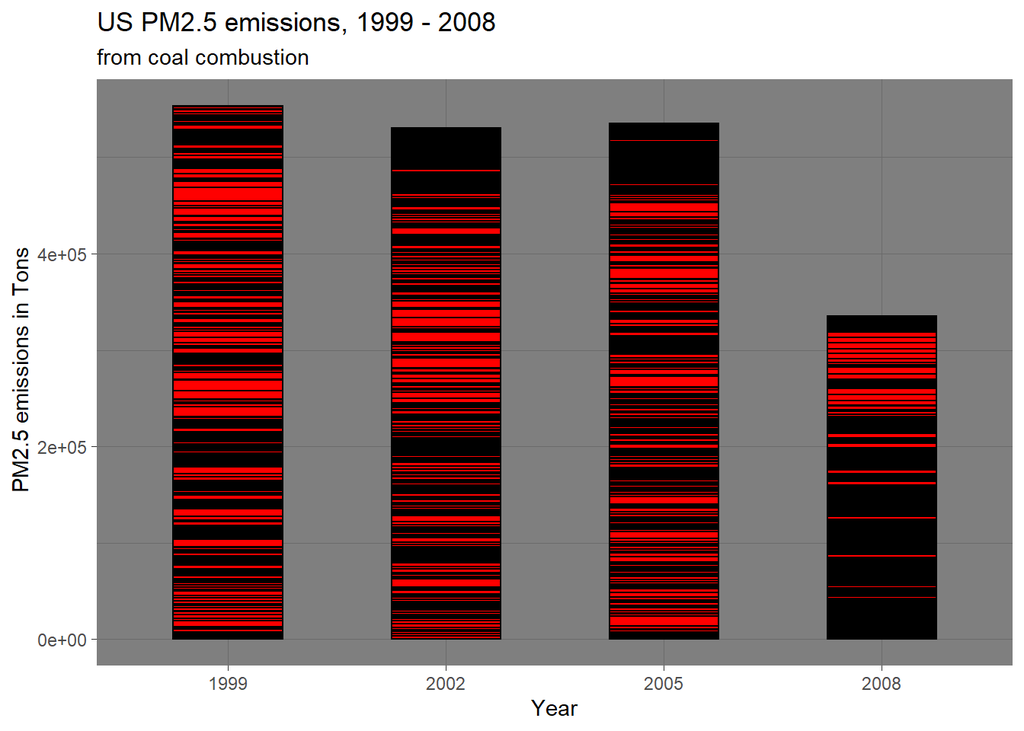

```r
setwd("C:/Users/angul/OneDrive/R/ExploreData/Data")

library(ggplot2)
library(dplyr)
library(RColorBrewer)

NEI <- readRDS("summarySCC_PM25.rds")
SCC <- readRDS("Source_Classification_Code.rds")

#[We have to filter the SCC data by coal in SCC Level 3 and combustion in SCC Level](https://www.cmascenter.org/smoke/documentation/2.7/html/ch02s03s05.html)

SCC_Coal_Comb <- SCC %>%
        filter(grepl('[Cc]ombustion', SCC.Level.One)) %>%
        filter(grepl("[Cc]oal", SCC.Level.Three)) %>%
        select(SCC, SCC.Level.One, SCC.Level.Three)

NEI_Coal_Comb <- inner_join(NEI, SCC_Coal_Comb, by = "SCC")

NEICoalComb_Bar <- ggplot(NEI_Coal_Comb, aes(factor(year), Emissions)) +
        geom_bar(stat = "identity", fill = "red" , width = 0.5, col= "black") + labs(x = "Year",
        y = " PM2.5 emissions in Tons", title = "US PM2.5 emissions, 1999 - 2008",
        subtitle = "from coal combustion" ) +
        theme(plot.title = element_text(size = 14),
              axis.title.x = element_text(size = 12),
              axis.title.y = element_text(size = 12)) +
        theme_dark() +
        ggsave("Q4_NEICoalComb_Bar.png", width = 25, height = 20, units = "cm")


print(NEICoalComb_Bar)
```

`scratch space`

```r
summary(SCC_Coal_Comb)
```

```
##        SCC                               SCC.Level.One
##  10100101: 1   External Combustion Boilers      :67
##  10100102: 1   Stationary Source Fuel Combustion:12
##  10100201: 1   Internal Combustion Engines      : 1
##  10100202: 1   Brick Kilns                      : 0
##  10100203: 1   Domestic Ammonia                 : 0
##  10100204: 1   Industrial Processes             : 0
##  (Other) :74   (Other)                          : 0
##                       SCC.Level.Three
##  Bituminous/Subbituminous Coal:60
##  Anthracite Coal              :14
##  Lignite Coal                 : 2
##  Waste Coal                   : 2
##  Coal-based Synfuel           : 1
##  Gasified Coal                : 1
##  (Other)                      : 0
```

```r
head(NEI_Coal_Comb)
```

```
##    fips        SCC Pollutant Emissions     type year
## 1 09001 2104001000  PM25-PRI     1.134 NONPOINT 1999
## 2 09003 2104001000  PM25-PRI     3.842 NONPOINT 1999
## 3 09005 2104001000  PM25-PRI     1.447 NONPOINT 1999
## 4 09007 2104001000  PM25-PRI     1.574 NONPOINT 1999
## 5 09009 2104001000  PM25-PRI     2.183 NONPOINT 1999
## 6 09011   10100217  PM25-PRI   479.907    POINT 1999
##                       SCC.Level.One               SCC.Level.Three
## 1 Stationary Source Fuel Combustion               Anthracite Coal
## 2 Stationary Source Fuel Combustion               Anthracite Coal
## 3 Stationary Source Fuel Combustion               Anthracite Coal
## 4 Stationary Source Fuel Combustion               Anthracite Coal
## 5 Stationary Source Fuel Combustion               Anthracite Coal
## 6       External Combustion Boilers Bituminous/Subbituminous Coal
```

```r
summary(NEI_Coal_Comb$Emissions)
```

```
##      Min.   1st Qu.    Median      Mean   3rd Qu.      Max.
##     0.000     0.000     0.072    48.422     1.540 14274.481
```

```r
print("The Clean Air Act programs have lowered national concentrations of P2.5 from coal by over 2e+05 Tons between 1999 and 2008.")
```

```
## [1] "The Clean Air Act programs have lowered national concentrations of P2.5 from coal by over 2e+05 Tons between 1999 and 2008."
```

### Q5.How have emissions from motor vehicle sources changed from 1999 to 2008 in Baltimore City?

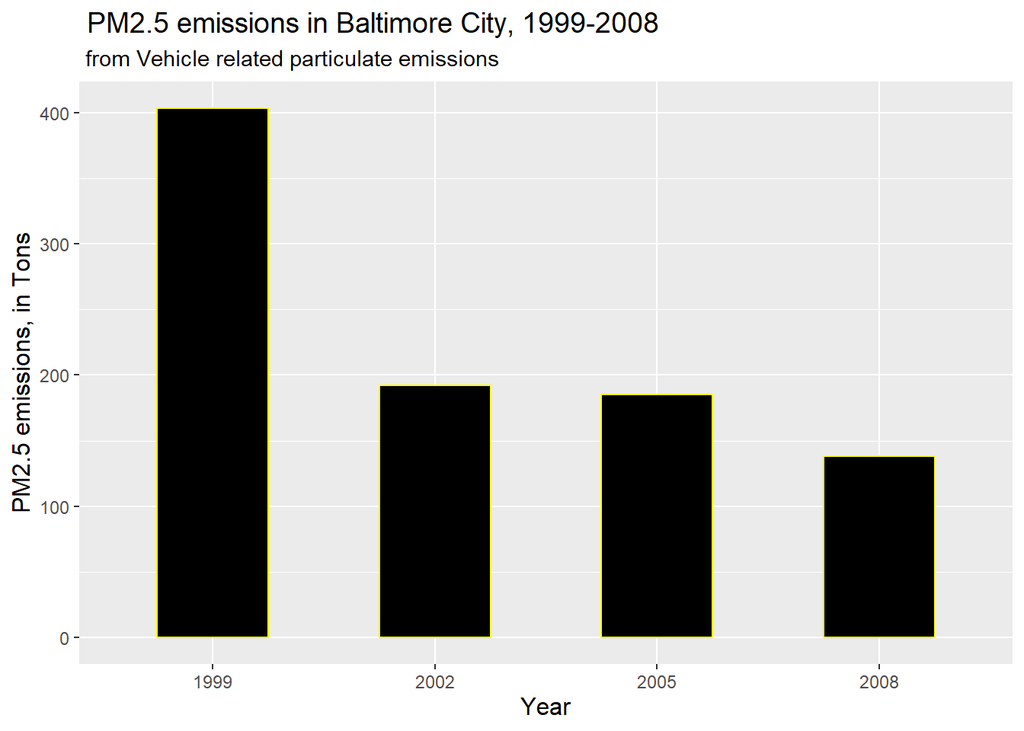

```r
setwd("C:/Users/angul/OneDrive/R/ExploreData/Data")

library(ggplot2)
library(dplyr)
library(RColorBrewer)

NEI <- readRDS("summarySCC_PM25.rds")
SCC <- readRDS("Source_Classification_Code.rds")

SCC_Vehicles <- SCC %>%
        filter(grepl('[Vv]ehicle', SCC.Level.Two)) %>%
        select(SCC, SCC.Level.Two)

Tot_Emi_24510_V <- NEI %>%
        filter(fips == "24510") %>%
        select(SCC, fips, Emissions, year) %>%
        inner_join(SCC_Vehicles, by = "SCC") %>%
        group_by(year) %>%
        summarise(Total_Emissions = sum(Emissions, na.rm = TRUE)) %>%
        select(Total_Emissions, year)
BaltimoreVehicles_bar <- ggplot(Tot_Emi_24510_V, aes(factor(year), Total_Emissions)) +
        geom_bar(stat = "identity", fill = "black", width = 0.5,
        col="yellow") + labs(x = "Year", y = "PM2.5 emissions, in Tons",
        title = " PM2.5 emissions in Baltimore City, 1999-2008",
        subtitle = " from Vehicle related particulate emissions") +
        theme(plot.title = element_text(size = 14),
              axis.title.x = element_text(size = 12),
              axis.title.y = element_text(size = 12)) +
        ggsave("Q5_BaltimoreVehicles_bar.png", width = 25, height = 20,
        units = "cm")

print(BaltimoreVehicles_bar)
```

`scratch space`

```r
head(Tot_Emi_24510_V)
```

```
## # A tibble: 4 x 2
##   Total_Emissions  year
##             <dbl> <int>
## 1            404.  1999
## 2            192.  2002
## 3            185.  2005
## 4            138.  2008
```

```r
print("Motor vehicle emissions dropped from 404 in 1999 to 138 Tons in 2008, in Baltimore City.")
```

```
## [1] "Motor vehicle emissions dropped from 404 in 1999 to 138 Tons in 2008, in Baltimore City."
```

### Q6. Compare emissions from motor vehicle sources in Baltimore City with emissions from motor vehicle sources in Los Angeles County, California ( fips == 06037). Which city has seen greater changes over time in motor vehicle emissions?

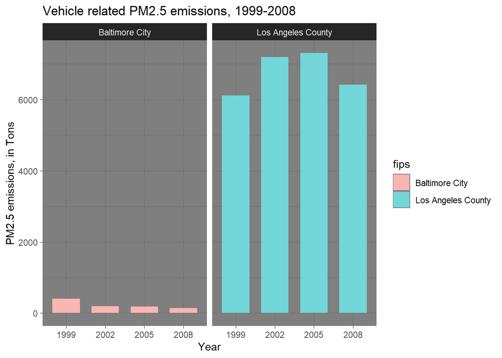

```r
setwd("C:/Users/angul/OneDrive/R/ExploreData/Data")

library(ggplot2)
library(dplyr)
library(RColorBrewer)

SCC_Vehicles <- SCC %>%
        filter(grepl('[Vv]ehicle', SCC.Level.Two)) %>%
        select(SCC, SCC.Level.Two)

Tot_Emi_Two_Locs <- NEI %>%
        filter(fips == "24510" | fips == "06037") %>%
        select(fips, SCC, Emissions, year) %>%
        inner_join(SCC_Vehicles, by = "SCC") %>%
        group_by(fips, year) %>%
        summarise(Total_Emissions = sum(Emissions, na.rm = TRUE)) %>%
        select(Total_Emissions, fips, year)
Tot_Emi_Two_Locs$fips <- gsub("24510", "Baltimore City", Tot_Emi_Two_Locs$fips)
Tot_Emi_Two_Locs$fips <- gsub("06037", "Los Angeles County", Tot_Emi_Two_Locs$fips)

Vehicle_BaltLA_bar <- ggplot(Tot_Emi_Two_Locs, aes(x = factor(year), y = Total_Emissions, fill = fips )) +
        geom_bar(stat = "identity", width = 0.7) +
        facet_grid(.~fips) +
        labs(x = "Year", y = "PM2.5 emissions, in Tons", title = "Vehicle related PM2.5 emissions, 1999-2008") +
        theme(plot.title = element_text(size = 14),
              axis.title.x = element_text(size = 12),
              axis.title.y = element_text(size = 12),
              strip.text.x = element_text(size = 12)) +
        scale_fill_hue(c=45, l=80) +
        theme_dark() +
        ggsave("Q6_Vehicle_BaltLA_bar.png", width = 25, height = 20, units = "cm")

print(Vehicle_BaltLA_bar)
```

`scratch space`

```r
print(summary(Tot_Emi_Two_Locs))
```

```
##  Total_Emissions      fips                year
##  Min.   : 138.2   Length:8           Min.   :1999
##  1st Qu.: 190.4   Class :character   1st Qu.:2001
##  Median :3256.7   Mode  :character   Median :2004
##  Mean   :3492.9                      Mean   :2004
##  3rd Qu.:6612.9                      3rd Qu.:2006
##  Max.   :7304.1                      Max.   :2008
```

```r
Tot_Emi_Two_Locs
```

```
## # A tibble: 8 x 3
## # Groups:   fips [2]
##   Total_Emissions fips                year
##             <dbl> <chr>              <int>
## 1           6110. Los Angeles County  1999
## 2           7189. Los Angeles County  2002
## 3           7304. Los Angeles County  2005
## 4           6421. Los Angeles County  2008
## 5            404. Baltimore City      1999
## 6            192. Baltimore City      2002
## 7            185. Baltimore City      2005
## 8            138. Baltimore City      2008
```

`scratch space`

```r
print((Tot_Emi_Two_Locs[4,1]/Tot_Emi_Two_Locs[8,1] +
Tot_Emi_Two_Locs[3,1]/Tot_Emi_Two_Locs[7,1] +
Tot_Emi_Two_Locs[2,1]/Tot_Emi_Two_Locs[6,1]+
Tot_Emi_Two_Locs[1,1]/Tot_Emi_Two_Locs[5,1])/4)
```

```
##   Total_Emissions
## 1        34.60322
```

```r
print("Vehicle related emission in Los Angeles County were on average 35 times that of Baltimore City, during the period 1999-2008")
```

```
## [1] "Vehicle related emission in Los Angeles County were on average 35 times that of Baltimore City, during the period 1999-2008"
```

```r
print("The change from 1999 to 2008 followed a steady downward trend  and resulted in a shift of: ")
```

```
## [1] "The change from 1999 to 2008 followed a steady downward trend  and resulted in a shift of: "
```

```r
print(Tot_Emi_Two_Locs[5,1]-Tot_Emi_Two_Locs[8,1])
```

```
##   Total_Emissions
## 1        265.5298
```

```r
print("in Baltimore City, while in Los Angeles County vehicle related emissions rose from 6110 to 7304 Tons from 1999 to 2005, then went down to 6421 Tons in 2008, this is an increase of: ")
```

```
## [1] "in Baltimore City, while in Los Angeles County vehicle related emissions rose from 6110 to 7304 Tons from 1999 to 2005, then went down to 6421 Tons in 2008, this is an increase of: "
```

```r
print(Tot_Emi_Two_Locs[1,1]-Tot_Emi_Two_Locs[4,1])
```

```
##   Total_Emissions
## 1        -311.327
```

```r
print("311 Tons of vehicle related emissions")
```

```
## [1] "311 Tons of vehicle related emissions"
```

```r
print("Vehicle related emission in Los Angeles County were on average 35 times that of Baltimore City, during the period 1999-2008. In Baltimore city there was a steady downward trend and resulted in a sheading of 266 Tons of PM2.5 emissions. While in Los Angeles County vehicle related emissions rose from 6110 to 7304 Tons from 1999 to 2005, then went down to 6421 Tons in 2008, this resulted in a net increase of 311 Tons of vehicle related emissions when comparing 1999 to 2008.")
```

[output not shown]

[Get the full EPA report here](https://www.epa.gov/sites/production/files/2015-07/documents/fullrept.pdf)